# Variation in PWS Pink Salmon Egg Take Over Time

Has Egg Take Timing Shifted?

Kyle Shedd

2024-03-26; updated 2024-04-05 write out cleaned eggtake data; update 2024-04-11 with Lorna’s cleaned data

# Objective

The objective of this R Notebook is to determine whether egg take date for hatchery collections (data provided by Heather Scannell, PWS Seine AMB) has contracted over time.

# Background

Will Hemstrom and Mark Christie at Purdue University have found a large-effect locus (*lrrc9*) for hatchery x hatchery and hatchery x natural comparisons, but not in natural x natural comparisons. Independently, and beforehand, Wes Larson and Pat Barry found strong evidence that *lrrc9* is tied to run timing in Auke Creek pink salmon. Based on their work and the pairwise Fst outlier data from Will (most of which involve VFDA hatchery, known early run timing), we have strong reason to believe that this region of the genome is associated with run timing. Here, I will be attempting to get collection-specific run timing data that is comparable across hatchery and stream collections so we can see how run timing correlates with *lrrc9* haplotypes.

# Setup

Load all necessary packages, as of 2023-08-11 Kyle switched to GCLr.

```r
rm(list = ls(all.names = TRUE))

if(!require("pacman")) install.packages("pacman"); library(pacman)

pacman::p_load(
  tidyverse,
  lubridate,
  scales,
  janitor,
  GCLr
)

knitr::opts_chunk$set(fig.width = 10)

# source("~/R/Functions.GCL.R")  # source GCL scripts, switched to GCLr package
.username = readLines("~/R/usr_pw.txt", n = 1)  # LOKI username
.password = readLines("~/R/usr_pw.txt" , n = 2)[[2]]  # LOKI password
```

# Import Data

## Egg take

Read in the egg take data from Heather Scannell, only includes data through 2021!

### VFDA

**NOTE** dates are ALL formatted as 2010, need to look into how to strip out M/D and then rejoin with `year`, and then extract the Julian date (`yday`).

```r
(
  eggtake_VFDA <-
    readxl::read_xls(
      path = "../data/run_timing/PWS Hatchery Performance Data - Working Data Set_hs_krs.xls",
      sheet = "VFDA Fecundity Data",
      range = "A3:N44",
      col_types = c(
        "numeric",
        rep("text", 2),
        rep("numeric", 5),
        "skip",
        rep("date", 3),
        rep("numeric", 2)
      )
    ) %>% janitor::clean_names() %>%
    dplyr::mutate(start_date = lubridate::as_date(egg_take_start),
                  end_date = lubridate::as_date(egg_take_end_date),
                  p50_date = lubridate::as_date(x50_percent_egg_take_date)) %>%
    dplyr::select(-egg_take_start, -egg_take_end_date, -x50_percent_egg_take_date)
)
```

| year | hatchery | species | weight_kg | length_cm_male | length_cm_female | fecundity | fecundity_weight | duration | egg_take_number | start_date | end_date | p50_date |
| --- | --- | --- | --- | --- | --- | --- | --- | --- | --- | --- | --- | --- |
| 1981 | VFDA | Pink | 1.960 | 48.15 | NA | 1882 | 960.2041 | 14 | 9976112 | 2010-07-13 | 2010-07-27 | 2010-07-20 |
| 1982 | VFDA | Pink | NA | NA | NA | 1878 | NA | NA | NA |  |  |  |
| 1983 | VFDA | Pink | 1.900 | 51.24 | 50.40 | 1915 | 1007.8947 | 24 | 12930976 | 2010-07-19 | 2010-08-12 | 2010-07-31 |
| 1984 | VFDA | Pink | 1.800 | 51.00 | NA | 1905 | 1058.3333 | 22 | 66650000 | 2010-07-16 | 2010-08-07 | 2010-07-27 |
| 1985 | VFDA | Pink | 1.470 | 18.62 | NA | 1647 | 1120.4082 | 32 | 96850000 | 2010-07-12 | 2010-08-13 | 2010-07-28 |
| 1986 | VFDA | Pink | 1.220 | 44.66 | 45.60 | 1433 | 1174.5902 | 35 | 64102894 | 2010-07-22 | 2010-08-26 | 2010-08-08 |
| 1987 | VFDA | Pink | 1.700 | 50.00 | 53.00 | 1746 | 1027.0588 | 22 | 163892205 | 2010-07-16 | 2010-08-07 | 2010-07-27 |
| 1988 | VFDA | Pink | 1.410 | 46.11 | 46.91 | 1742 | 1235.4610 | 21 | 154606013 | 2010-07-20 | 2010-08-10 | 2010-07-30 |
| 1989 | VFDA | Pink | 1.410 | 46.10 | 46.90 | 1649 | 1169.5035 | 38 | 142826728 | 2010-07-15 | 2010-08-22 | 2010-08-03 |
| 1990 | VFDA | Pink | 1.370 | 45.50 | 45.40 | 1600 | 1167.8832 | 25 | 159448601 | 2010-07-20 | 2010-08-14 | 2010-08-01 |

[output cut: 31 more lines]

### AFK

**NOTE** dates are ALL formatted as 2010, need to look into how to strip out M/D and then rejoin with `year`, and then extract the Julian date (`yday`).

```r
(
  eggtake_AFK <-
    readxl::read_xls(
      path = "../data/run_timing/PWS Hatchery Performance Data - Working Data Set_hs_krs.xls",
      sheet = "AFK Fecundity Data",
      range = "A3:K51",
      col_types = c(
        "numeric",
        rep("text", 2),
        rep("numeric", 4),
        rep("date", 3),
        "numeric"
      )
    ) %>% janitor::clean_names() %>%
    dplyr::mutate(start_date = lubridate::as_date(egg_take_start),
                  end_date = lubridate::as_date(egg_take_end_date),
                  p50_date = lubridate::as_date(x50_percent_egg_take_date),
                  p50_julian = lubridate::yday(p50_date)) %>%
    dplyr::select(-egg_take_start, -egg_take_end_date, -x50_percent_egg_take_date)
)
```

| year | hatchery | species | weight_kg | length_cm_male | length_cm_female | fecundity | egg_take_number | start_date | end_date | p50_date | p50_julian |
| --- | --- | --- | --- | --- | --- | --- | --- | --- | --- | --- | --- |
| 1975 | AFK | Pink | NA | NA | NA | NA | NA |  |  |  | NA |
| 1976 | AFK | Pink | NA | NA | NA | 1552 | NA | 2010-08-18 | 2010-09-08 | 2010-08-28 | 240 |
| 1976 | AFK | Pink | NA | NA | NA | 1619 | 14028904 | 2010-08-25 | 2010-09-21 | 2010-09-07 | 250 |
| 1977 | AFK | Pink | 1.80 | NA | NA | NA | NA |  |  |  | NA |
| 1978 | AFK | Pink | 1.59 | 46.90 | NA | 1782 | 28645626 | 2010-07-25 | 2010-09-01 | 2010-08-13 | 225 |
| 1979 | AFK | Pink | 1.55 | 48.05 | NA | 1660 | 28401415 | 2010-07-30 | 2010-09-14 | 2010-08-22 | 234 |
| 1980 | AFK | Pink | 1.50 | 46.67 | NA | 1670 | 94689000 | 2010-08-24 | 2010-08-26 | 2010-08-25 | 237 |
| 1981 | AFK | Pink | 1.61 | 47.80 | NA | 1675 | 143500000 | 2010-08-26 | 2010-09-18 | 2010-09-06 | 249 |
| 1982 | AFK | Pink | 1.55 | 46.17 | NA | 1565 | 129615000 | 2010-09-04 | 2010-09-21 | 2010-09-12 | 255 |
| 1983 | AFK | Pink | 1.36 | 46.30 | NA | 1618 | 89752270 | 2010-08-29 | 2010-09-16 | 2010-09-07 | 250 |

[output cut: 38 more lines]

### WNH

**NOTE** dates are mostly formatted as 2010, need to look into how to strip out M/D and then rejoin with `year`, and then extract the Julian date (`yday`).

```r
(
  eggtake_WNH <-
    readxl::read_xls(
      path = "../data/run_timing/PWS Hatchery Performance Data - Working Data Set_hs_krs.xls",
      sheet = "WNH Fecundity Data",
      range = "A2:N31",
      col_types = c(
        "numeric",
        rep("text", 2),
        rep("numeric", 5),
        "text",
        rep("date", 3),
        rep("numeric", 2)
      )
    ) %>% janitor::clean_names() %>%
    dplyr::mutate(start_date = lubridate::as_date(egg_take_start),
                  end_date = lubridate::as_date(egg_take_end_date),
                  p50_date = lubridate::as_date(x50_percent_egg_take_date),
                  p50_julian = lubridate::yday(p50_date)) %>%
    dplyr::select(-egg_take_start, -egg_take_end_date, -x50_percent_egg_take_date, -x9)
)
```

| year | hatchery | species | weight_kg | length_cm_male | length_cm_female | fecundity | fecundity_weight | duration | egg_take_number | start_date | end_date | p50_date | p50_julian |
| --- | --- | --- | --- | --- | --- | --- | --- | --- | --- | --- | --- | --- | --- |
| 1993 | WNH | Pink | NA | NA | NA | NA | NA | NA | NA |  |  |  | NA |
| 1994 | WNH | Pink | 1.59 | NA | NA | 1736 | 1091.8239 | 21 | 188110652 | 2010-08-22 | 2010-09-12 | 2010-09-01 | 244 |
| 1995 | WNH | Pink | 1.70 | 46.5 | 47.9 | 1513 | 890.0000 | 23 | 188506249 | 2010-08-22 | 2010-09-14 | 2010-09-02 | 245 |
| 1996 | WNH | Pink | 1.63 | 47.6 | NA | 1528 | 937.4233 | 21 | 176216859 | 2010-08-23 | 2010-09-13 | 2010-09-02 | 245 |
| 1997 | WNH | Pink | 1.80 | NA | NA | 1495 | 830.5556 | 26 | 229372959 | 2010-08-20 | 2010-09-15 | 2010-09-02 | 245 |
| 1998 | WNH | Pink | 1.70 | 46.1 | 47.8 | 1515 | 891.1765 | 16 | 130197003 | 2010-08-22 | 2010-09-07 | 2010-08-30 | 242 |
| 1999 | WNH | Pink | 1.30 | 43.3 | 43.3 | 1111 | 854.6154 | 20 | 130003972 | 2010-08-27 | 2010-09-16 | 2010-09-06 | 249 |
| 2000 | WNH | Pink | 1.70 | 47.9 | 47.9 | 1555 | 914.7059 | 16 | 132447650 | 2010-08-25 | 2010-09-10 | 2010-09-02 | 245 |
| 2001 | WNH | Pink | 1.50 | 47.6 | 48.0 | 1453 | 968.6667 | 24 | 119081166 | 2010-08-27 | 2010-09-20 | 2010-09-08 | 251 |
| 2002 | WNH | Pink | 1.80 | 47.6 | 48.0 | 1466 | 814.4444 | 17 | 132655040 | 2010-08-27 | 2010-09-13 | 2010-09-04 | 247 |

[output cut: 19 more lines]

### CCH

**NOTE** dates are mostly formatted as 2010, need to look into how to strip out M/D and then rejoin with `year`, and then extract the Julian date (`yday`).

```r
(
  eggtake_CCH <-
    readxl::read_xls(
      path = "../data/run_timing/PWS Hatchery Performance Data - Working Data Set_hs_krs.xls",
      sheet = "CCH Fecundity Data",
      range = "A3:N50",
      col_types = c(
        "numeric",
        rep("text", 2),
        rep("numeric", 6),
        rep("date", 3),
        rep("numeric", 2)
      )
    ) %>% janitor::clean_names() %>%
    dplyr::mutate(start_date = lubridate::as_date(egg_take_start),
                  end_date = lubridate::as_date(egg_take_end_date),
                  p50_date = lubridate::as_date(x50_percent_egg_take_date),
                  p50_julian = lubridate::yday(p50_date)) %>%
    dplyr::select(-egg_take_start, -egg_take_end_date, -x50_percent_egg_take_date)
)
```

| year | hatchery | species | weight_kg | length_cm_male | length_cm_female | fecundity | swimup_weight_g | swimup_length_mm | duration | egg_take_number | start_date | end_date | p50_date | p50_julian |
| --- | --- | --- | --- | --- | --- | --- | --- | --- | --- | --- | --- | --- | --- | --- |
| 1975 | CCH | Pink | NA | NA | NA | NA | NA | NA | NA | NA |  |  |  | NA |
| 1976 | CCH | Pink | NA | NA | NA | NA | NA | NA | NA | NA |  |  |  | NA |
| 1977 | CCH | Pink | NA | NA | NA | NA | NA | NA | NA | NA |  |  |  | NA |
| 1978 | CCH | Pink | NA | NA | NA | NA | NA | NA | NA | NA |  |  |  | NA |
| 1979 | CCH | Pink | NA | NA | NA | NA | NA | NA | NA | NA |  |  |  | NA |
| 1980 | CCH | Pink | NA | NA | NA | NA | NA | NA | NA | 21474000 |  |  |  | NA |
| 1981 | CCH | Pink | NA | NA | NA | NA | NA | NA | NA | 48991000 |  |  |  | NA |
| 1982 | CCH | Pink | NA | NA | NA | NA | NA | NA | NA | 22461000 |  |  |  | NA |
| 1983 | CCH | Pink | NA | NA | NA | NA | NA | NA | NA | 32596000 |  |  |  | NA |
| 1984 | CCH | Pink | NA | NA | NA | NA | NA | NA | NA | 37200000 |  |  |  | NA |

[output cut: 37 more lines]

# Manipulate Data

## Egg take

### VFDA

Fix dates to correct year, calculate Julian date for p50 egg take for each year.

```r
(
  eggtake_VFDA_clean <- eggtake_VFDA %>%
    dplyr::mutate(
      p50_date = as.character(p50_date),
      p50_date = stringr::str_sub(
        string = p50_date,
        start = 6,
        end = -1
      ),
      p50_date = stringr::str_c(year, p50_date, sep = "-"),
      p50_date = lubridate::as_date(p50_date),
      p50_julian = lubridate::yday(p50_date),
      start_date = as.character(start_date),
      start_date = stringr::str_sub(
        string = start_date,
        start = 6,
        end = -1
      ),
      start_date = stringr::str_c(year, start_date, sep = "-"),
      start_date = lubridate::as_date(start_date),
      start_julian = lubridate::yday(start_date),
      end_date = as.character(end_date),
      end_date = stringr::str_sub(
        string = end_date,
        start = 6,
        end = -1
      ),
      end_date = stringr::str_c(year, end_date, sep = "-"),
      end_date = lubridate::as_date(end_date),
      end_julian = lubridate::yday(end_date),
      duration = end_date - start_date,
      lineage = dplyr::case_when(year %% 2 == 0 ~ "even",
                                 year %% 2 == 1 ~ "odd",
                                 TRUE ~ NA_character_)
    ) %>%
    dplyr::select(hatchery, year, lineage, start_date, p50_date, end_date, start_julian, p50_julian, end_julian, duration, fecundity)
)
```

| hatchery | year | lineage | start_date | p50_date | end_date | start_julian | p50_julian | end_julian | duration | fecundity |
| --- | --- | --- | --- | --- | --- | --- | --- | --- | --- | --- |
| VFDA | 1981 | odd | 1981-07-13 | 1981-07-20 | 1981-07-27 | 194 | 201 | 208 | 14 days | 1882 |
| VFDA | 1982 | even |  |  |  | NA | NA | NA | NA days | 1878 |
| VFDA | 1983 | odd | 1983-07-19 | 1983-07-31 | 1983-08-12 | 200 | 212 | 224 | 24 days | 1915 |
| VFDA | 1984 | even | 1984-07-16 | 1984-07-27 | 1984-08-07 | 198 | 209 | 220 | 22 days | 1905 |
| VFDA | 1985 | odd | 1985-07-12 | 1985-07-28 | 1985-08-13 | 193 | 209 | 225 | 32 days | 1647 |
| VFDA | 1986 | even | 1986-07-22 | 1986-08-08 | 1986-08-26 | 203 | 220 | 238 | 35 days | 1433 |
| VFDA | 1987 | odd | 1987-07-16 | 1987-07-27 | 1987-08-07 | 197 | 208 | 219 | 22 days | 1746 |
| VFDA | 1988 | even | 1988-07-20 | 1988-07-30 | 1988-08-10 | 202 | 212 | 223 | 21 days | 1742 |
| VFDA | 1989 | odd | 1989-07-15 | 1989-08-03 | 1989-08-22 | 196 | 215 | 234 | 38 days | 1649 |
| VFDA | 1990 | even | 1990-07-20 | 1990-08-01 | 1990-08-14 | 201 | 213 | 226 | 25 days | 1600 |

[output cut: 31 more lines]

### AFK

Fix dates to correct year, calculate Julian date for p50 egg take for each year.

```r
(
  eggtake_AFK_clean <- eggtake_AFK %>%
    dplyr::mutate(
      p50_date = as.character(p50_date),
      p50_date = stringr::str_sub(
        string = p50_date,
        start = 6,
        end = -1
      ),
      p50_date = stringr::str_c(year, p50_date, sep = "-"),
      p50_date = lubridate::as_date(p50_date),
      p50_julian = lubridate::yday(p50_date),
      start_date = as.character(start_date),
      start_date = stringr::str_sub(
        string = start_date,
        start = 6,
        end = -1
      ),
      start_date = stringr::str_c(year, start_date, sep = "-"),
      start_date = lubridate::as_date(start_date),
      start_julian = lubridate::yday(start_date),
      end_date = as.character(end_date),
      end_date = stringr::str_sub(
        string = end_date,
        start = 6,
        end = -1
      ),
      end_date = stringr::str_c(year, end_date, sep = "-"),
      end_date = lubridate::as_date(end_date),
      end_julian = lubridate::yday(end_date),
      duration = end_date - start_date,
      lineage = dplyr::case_when(year %% 2 == 0 ~ "even",
                                 year %% 2 == 1 ~ "odd",
                                 TRUE ~ NA_character_)
    ) %>%
    dplyr::select(hatchery, year, lineage, start_date, p50_date, end_date, start_julian, p50_julian, end_julian, duration, fecundity)
)
```

| hatchery | year | lineage | start_date | p50_date | end_date | start_julian | p50_julian | end_julian | duration | fecundity |
| --- | --- | --- | --- | --- | --- | --- | --- | --- | --- | --- |
| AFK | 1975 | odd |  |  |  | NA | NA | NA | NA days | NA |
| AFK | 1976 | even | 1976-08-18 | 1976-08-28 | 1976-09-08 | 231 | 241 | 252 | 21 days | 1552 |
| AFK | 1976 | even | 1976-08-25 | 1976-09-07 | 1976-09-21 | 238 | 251 | 265 | 27 days | 1619 |
| AFK | 1977 | odd |  |  |  | NA | NA | NA | NA days | NA |
| AFK | 1978 | even | 1978-07-25 | 1978-08-13 | 1978-09-01 | 206 | 225 | 244 | 38 days | 1782 |
| AFK | 1979 | odd | 1979-07-30 | 1979-08-22 | 1979-09-14 | 211 | 234 | 257 | 46 days | 1660 |
| AFK | 1980 | even | 1980-08-24 | 1980-08-25 | 1980-08-26 | 237 | 238 | 239 | 2 days | 1670 |
| AFK | 1981 | odd | 1981-08-26 | 1981-09-06 | 1981-09-18 | 238 | 249 | 261 | 23 days | 1675 |
| AFK | 1982 | even | 1982-09-04 | 1982-09-12 | 1982-09-21 | 247 | 255 | 264 | 17 days | 1565 |
| AFK | 1983 | odd | 1983-08-29 | 1983-09-07 | 1983-09-16 | 241 | 250 | 259 | 18 days | 1618 |

[output cut: 38 more lines]

### WNH

Fix dates to correct year, calculate Julian date for p50 egg take for each year.

```r
(
  eggtake_WNH_clean <- eggtake_WNH %>%
    dplyr::mutate(
      p50_date = as.character(p50_date),
      p50_date = stringr::str_sub(
        string = p50_date,
        start = 6,
        end = -1
      ),
      p50_date = stringr::str_c(year, p50_date, sep = "-"),
      p50_date = lubridate::as_date(p50_date),
      p50_julian = lubridate::yday(p50_date),
      start_date = as.character(start_date),
      start_date = stringr::str_sub(
        string = start_date,
        start = 6,
        end = -1
      ),
      start_date = stringr::str_c(year, start_date, sep = "-"),
      start_date = lubridate::as_date(start_date),
      start_julian = lubridate::yday(start_date),
      end_date = as.character(end_date),
      end_date = stringr::str_sub(
        string = end_date,
        start = 6,
        end = -1
      ),
      end_date = stringr::str_c(year, end_date, sep = "-"),
      end_date = lubridate::as_date(end_date),
      end_julian = lubridate::yday(end_date),
      duration = end_date - start_date,
      lineage = dplyr::case_when(year %% 2 == 0 ~ "even",
                                 year %% 2 == 1 ~ "odd",
                                 TRUE ~ NA_character_)
    ) %>%
    dplyr::select(hatchery, year, lineage, start_date, p50_date, end_date, start_julian, p50_julian, end_julian, duration, fecundity)
)
```

| hatchery | year | lineage | start_date | p50_date | end_date | start_julian | p50_julian | end_julian | duration | fecundity |
| --- | --- | --- | --- | --- | --- | --- | --- | --- | --- | --- |
| WNH | 1993 | odd |  |  |  | NA | NA | NA | NA days | NA |
| WNH | 1994 | even | 1994-08-22 | 1994-09-01 | 1994-09-12 | 234 | 244 | 255 | 21 days | 1736 |
| WNH | 1995 | odd | 1995-08-22 | 1995-09-02 | 1995-09-14 | 234 | 245 | 257 | 23 days | 1513 |
| WNH | 1996 | even | 1996-08-23 | 1996-09-02 | 1996-09-13 | 236 | 246 | 257 | 21 days | 1528 |
| WNH | 1997 | odd | 1997-08-20 | 1997-09-02 | 1997-09-15 | 232 | 245 | 258 | 26 days | 1495 |
| WNH | 1998 | even | 1998-08-22 | 1998-08-30 | 1998-09-07 | 234 | 242 | 250 | 16 days | 1515 |
| WNH | 1999 | odd | 1999-08-27 | 1999-09-06 | 1999-09-16 | 239 | 249 | 259 | 20 days | 1111 |
| WNH | 2000 | even | 2000-08-25 | 2000-09-02 | 2000-09-10 | 238 | 246 | 254 | 16 days | 1555 |
| WNH | 2001 | odd | 2001-08-27 | 2001-09-08 | 2001-09-20 | 239 | 251 | 263 | 24 days | 1453 |
| WNH | 2002 | even | 2002-08-27 | 2002-09-04 | 2002-09-13 | 239 | 247 | 256 | 17 days | 1466 |

[output cut: 19 more lines]

### CCH

Fix dates to correct year, calculate Julian date for p50 egg take for each year.

```r
(
  eggtake_CCH_clean <- eggtake_CCH %>%
    dplyr::mutate(
      p50_date = as.character(p50_date),
      p50_date = stringr::str_sub(
        string = p50_date,
        start = 6,
        end = -1
      ),
      p50_date = stringr::str_c(year, p50_date, sep = "-"),
      p50_date = lubridate::as_date(p50_date),
      p50_julian = lubridate::yday(p50_date),
      start_date = as.character(start_date),
      start_date = stringr::str_sub(
        string = start_date,
        start = 6,
        end = -1
      ),
      start_date = stringr::str_c(year, start_date, sep = "-"),
      start_date = lubridate::as_date(start_date),
      start_julian = lubridate::yday(start_date),
      end_date = as.character(end_date),
      end_date = stringr::str_sub(
        string = end_date,
        start = 6,
        end = -1
      ),
      end_date = stringr::str_c(year, end_date, sep = "-"),
      end_date = lubridate::as_date(end_date),
      end_julian = lubridate::yday(end_date),
      duration = end_date - start_date,
      lineage = dplyr::case_when(year %% 2 == 0 ~ "even",
                                 year %% 2 == 1 ~ "odd",
                                 TRUE ~ NA_character_)
    ) %>%
    dplyr::select(hatchery, year, lineage, start_date, p50_date, end_date, start_julian, p50_julian, end_julian, duration, fecundity)
)
```

| hatchery | year | lineage | start_date | p50_date | end_date | start_julian | p50_julian | end_julian | duration | fecundity |
| --- | --- | --- | --- | --- | --- | --- | --- | --- | --- | --- |
| CCH | 1975 | odd |  |  |  | NA | NA | NA | NA days | NA |
| CCH | 1976 | even |  |  |  | NA | NA | NA | NA days | NA |
| CCH | 1977 | odd |  |  |  | NA | NA | NA | NA days | NA |
| CCH | 1978 | even |  |  |  | NA | NA | NA | NA days | NA |
| CCH | 1979 | odd |  |  |  | NA | NA | NA | NA days | NA |
| CCH | 1980 | even |  |  |  | NA | NA | NA | NA days | NA |
| CCH | 1981 | odd |  |  |  | NA | NA | NA | NA days | NA |
| CCH | 1982 | even |  |  |  | NA | NA | NA | NA days | NA |
| CCH | 1983 | odd |  |  |  | NA | NA | NA | NA days | NA |
| CCH | 1984 | even |  |  |  | NA | NA | NA | NA days | NA |

[output cut: 37 more lines]

### Bind

```r
eggtake_clean <- dplyr::bind_rows(eggtake_AFK_clean, eggtake_WNH_clean, eggtake_CCH_clean, eggtake_VFDA_clean)
readr::write_csv(x = eggtake_clean, file = "../output/PWS_hatchery_eggtake_cleaned_20240405.csv")
```

Check p50 dates

| p50_julian_check | n |
| --- | --- |
| TRUE | 146 |
| NA | 19 |

Whew, all okay, so long as I used `floor` instead of `mean`.

Sent this `PWS_hatchery_eggtake_cleaned_20240405.csv` to Lorna Wilson (PNP planning/permitting coordinator - Juneau) on 2024-04-05 to double check the excel data I received from Heather Scannel (PWS Seine AMB - Cordova) with the official PNP database. Want to make sure that I have the correct information for Will Hemstrom and Mark Christie for the WGR *lrrc9* manuscript.

# Re-Import Cleaned Data

```r
(
  eggtake <-
    readxl::read_excel(
      path = "../output/PWS_hatchery_eggtake_cleaned_20240410.xlsx",
      sheet = 1,
      col_types = c(
        "text",
        "numeric",
        "text",
        rep("date", 3),
        rep("numeric", 5),
        "text",
        "numeric"
      ),
      na = "NA"
    )
)
```

| hatchery | year | lineage | start_date | p50_date | end_date | start_julian | p50_julian | end_julian | duration | fecundity | Note | Founding brood? |
| --- | --- | --- | --- | --- | --- | --- | --- | --- | --- | --- | --- | --- |
| AFK | 1975 | odd | 1975-08-28 | 1975-09-04 | 1975-09-11 | 240 | 247 | 254 | 15 | NA | NA | 1 |
| AFK | 1976 | even | 1976-08-18 | 1976-08-28 | 1976-09-08 | 231 | 241 | 252 | 22 | 1552 | 704,626 eggs taken | 1 |
| AFK | 1976 | even | 1976-08-25 | 1976-09-07 | 1976-09-21 | 238 | 251 | 265 | 28 | 1619 | 14.7 million eggs taken | 1 |
| AFK | 1977 | odd | 1977-08-22 | 1977-09-02 | 1977-09-14 | 234 | 245 | 257 | 24 | NA | NA | 1 |
| AFK | 1978 | even | 1978-07-25 | 1978-08-13 | 1978-09-01 | 206 | 225 | 244 | 39 | 1782 | NA | NA |
| AFK | 1979 | odd | 1979-07-30 | 1979-08-22 | 1979-09-14 | 211 | 234 | 257 | 47 | 1660 | NA | NA |
| AFK | 1980 | even | 1980-08-24 | 1980-08-25 | 1980-08-26 | 237 | 238 | 239 | 3 | 1670 | NA | NA |
| AFK | 1981 | odd | 1981-08-26 | 1981-09-06 | 1981-09-18 | 238 | 249 | 261 | 24 | 1675 | NA | NA |
| AFK | 1982 | even | 1982-09-04 | 1982-09-12 | 1982-09-21 | 247 | 255 | 264 | 18 | 1565 | NA | NA |
| AFK | 1983 | odd | 1983-08-29 | 1983-09-07 | 1983-09-16 | 241 | 250 | 259 | 19 | 1618 | NA | NA |

[output cut: 155 more lines]

Check out founding brood years.

| hatchery | year | lineage | start_date | p50_date | end_date | start_julian | p50_julian | end_julian | duration | fecundity | Note | Founding brood? |
| --- | --- | --- | --- | --- | --- | --- | --- | --- | --- | --- | --- | --- |
| AFK | 1975 | odd | 1975-08-28 | 1975-09-04 | 1975-09-11 | 240 | 247 | 254 | 15 | NA | NA | 1 |
| AFK | 1976 | even | 1976-08-18 | 1976-08-28 | 1976-09-08 | 231 | 241 | 252 | 22 | 1552 | 704,626 eggs taken | 1 |
| AFK | 1976 | even | 1976-08-25 | 1976-09-07 | 1976-09-21 | 238 | 251 | 265 | 28 | 1619 | 14.7 million eggs taken | 1 |
| AFK | 1977 | odd | 1977-08-22 | 1977-09-02 | 1977-09-14 | 234 | 245 | 257 | 24 | NA | NA | 1 |
| CCH | 1978 | even |  |  |  | NA | NA | NA | NA | NA | NA | 1 |
| CCH | 1979 | odd |  |  |  | NA | NA | NA | NA | NA | NA | 1 |
| CCH | 1980 | even |  |  |  | NA | NA | NA | NA | NA | NA | 1 |
| VFDA | 1981 | odd | 1981-07-13 | 1981-07-20 | 1981-07-27 | 194 | 201 | 208 | 15 | 1882 | NA | 1 |
| VFDA | 1982 | even | 1982-07-16 | 1982-07-26 | 1982-08-06 | 197 | 207 | 218 | 22 | 1878 | NA | 1 |

Need to fix AFK 1976, take earliest start and latest end dates.

```r
eggtake_clean <- eggtake %>%
  dplyr::select(hatchery:duration) %>%
  dplyr::filter(year == 1976 & hatchery == "AFK") %>%
  dplyr::mutate(start_date = min(start_date),
                end_date = max(end_date),
                start_julian = lubridate::yday(start_date),
                end_julian = lubridate::yday(end_date),
                p50_julian = floor((start_julian + end_julian) / 2),
                duration = end_julian - start_julian + 1,
                p50_date = lubridate::as_date(p50_julian, origin = "1976-01-01")) %>%
  dplyr::distinct() %>%
  dplyr::bind_rows(eggtake %>% dplyr::filter(!(year == 1976 & hatchery == "AFK"))) %>%
  dplyr::arrange(hatchery, year)
```

# Plot

Plot start/stop egg take dates over time as ribbon charts.

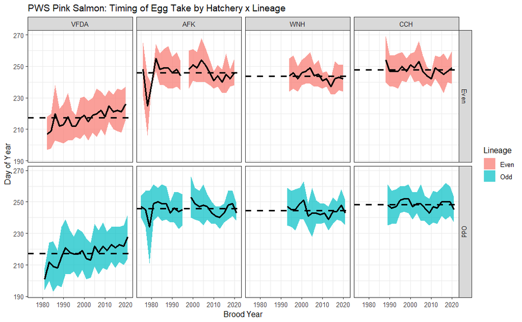

```r
eggtake_p50_mean <- eggtake_clean %>%
  dplyr::mutate(lineage = stringr::str_to_sentence(lineage),
                hatchery = factor(x = hatchery, levels = c("VFDA", "AFK", "WNH", "CCH"))) %>%
  dplyr::group_by(hatchery, lineage) %>%
  dplyr::summarise(mean_p50 = mean(p50_julian, na.rm = TRUE), .groups = "drop")

eggtake_clean %>%
  dplyr::mutate(lineage = stringr::str_to_sentence(lineage),
                hatchery = factor(x = hatchery, levels = c("VFDA", "AFK", "WNH", "CCH"))) %>%
  ggplot2::ggplot(ggplot2::aes(x = year, ymin = start_julian, y = p50_julian, ymax = end_julian, fill = lineage)) +
  ggplot2::geom_ribbon(alpha = 0.7) +
  ggplot2::geom_line(lwd = 1) +
  ggplot2::geom_hline(data = eggtake_p50_mean, ggplot2::aes(yintercept = mean_p50), lwd = 1, lty = 2) +
  # ggplot2::geom_smooth(method = "lm", se = FALSE) +
  ggplot2::theme_bw() +
  ggplot2::labs(x = "Brood Year", y = "Day of Year", fill = "Lineage", title = "PWS Pink Salmon: Timing of Egg Take by Hatchery x Lineage") +
  ggplot2::facet_grid(rows = dplyr::vars(lineage), cols = dplyr::vars(hatchery))
```

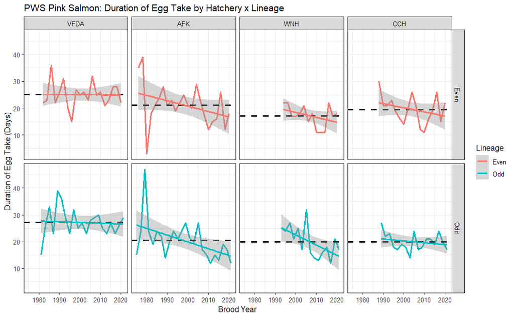

```r
eggtake_duration_mean <- eggtake_clean %>%
  dplyr::mutate(lineage = stringr::str_to_sentence(lineage),
                hatchery = factor(x = hatchery, levels = c("VFDA", "AFK", "WNH", "CCH"))) %>%
  dplyr::group_by(hatchery, lineage) %>%
  dplyr::summarise(mean_duration = mean(duration, na.rm = TRUE), .groups = "drop")

eggtake_clean %>%
  dplyr::mutate(lineage = stringr::str_to_sentence(lineage),
                hatchery = factor(x = hatchery, levels = c("VFDA", "AFK", "WNH", "CCH"))) %>%
  dplyr::filter(!is.na(duration)) %>%
  ggplot2::ggplot(ggplot2::aes(x = year, y = duration, colour = lineage)) +
  ggplot2::geom_line(lwd = 1) +
  ggplot2::geom_hline(data = eggtake_duration_mean, ggplot2::aes(yintercept = mean_duration), lwd = 1, lty = 2) +
  ggplot2::geom_smooth(method = "lm", lty = 1) +
  ggplot2::theme_bw() +
  ggplot2::labs(x = "Brood Year", y = "Duration of Egg Take (Days)", colour = "Lineage", title = "PWS Pink Salmon: Duration of Egg Take by Hatchery x Lineage") +
  ggplot2::facet_grid(rows = dplyr::vars(lineage), cols = dplyr::vars(hatchery))
```

# Conclusion

End